# Overview:

SVHN is a real-world image dataset for developing machine learning and object recognition algorithms with minimal requirement on data formatting but comes from a significantly harder, unsolved, real world problem (recognizing digits and numbers in natural scene images). SVHN is obtained from house numbers in Google Street View images.

# Image classification in the SVHN Dataset using Neural network

```python
#import the necessary libraries
import pandas as pd
import numpy as np
import h5py
import matplotlib.pyplot as plt
from sklearn.metrics import classification_report
import tensorflow as tf
tf.reset_default_graph()
tf.set_random_seed(1)
```

```python
filename = 'E:\\chrome downloads\\PGP-AIML\\Introduction to Neural Network and Deep Learning\\project\\SVHN_single_grey1.h5'
```

```python
#To open and read data we use the same File method in read mode, r
hdf = h5py.File(filename,'r')
```

```python
#To see what data is in this file, we can call the keys() method on the file object.
list(hdf.keys())
```

```
['X_test', 'X_train', 'X_val', 'y_test', 'y_train', 'y_val']
```

```python
#We can then grab each dataset we created above using the get method, specifying the name.
X_test = np.array(hdf.get('X_test'))
X_train = np.array(hdf.get('X_train'))
y_test = np.array(hdf.get('y_test'))
y_train = np.array(hdf.get('y_train'))
```

```python
print("X_train Shape::",X_train.shape)
print("y_train shape::",y_train.shape)
print("X_test shape::",X_test.shape)
print("y_test shape::",y_test.shape)
```

```
X_train Shape:: (42000, 32, 32)
y_train shape:: (42000,)
X_test shape:: (18000, 32, 32)
y_test shape:: (18000,)
```

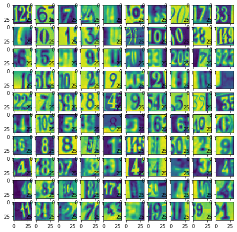

```python
#display the images from train dataset
fig = plt.figure(figsize=(8,8))
columns = 10
rows = 10
for i in range(1,columns*rows+1):
  img = X_train[i-1]
  fig.add_subplot(rows,columns,i)
  plt.imshow(img)
plt.show()
```

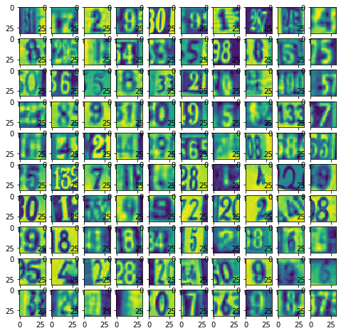

```python
#display the images from test dataset
fig = plt.figure(figsize=(8,8))
columns = 10
rows = 10
for i in range(1,columns*rows +1):
  img = X_test[i-1]
  fig.add_subplot(rows,columns,i)
  plt.imshow(img)
plt.show()
```

NEURAL NETWORK FROM SCRATCH

# Fully Connected Layer (Linear Layer)

```python
class Linear():
    def __init__(self, in_size, out_size):
        self.W = np.random.randn(in_size, out_size) * 0.01
        self.b = np.zeros((1, out_size))
        self.params = [self.W, self.b]
        self.gradW = None
        self.gradB = None
        self.gradInput = None

    def forward(self, X):
        self.X = X
        self.output = np.dot(X, self.W) + self.b
        return self.output

    def backward(self, nextgrad):
        self.gradW = np.dot(self.X.T, nextgrad)
        self.gradB = np.sum(nextgrad, axis=0)
        self.gradInput = np.dot(nextgrad, self.W.T)
        return self.gradInput, [self.gradW, self.gradB]
```

# Rectified Linear Activation Layer (ReLU)

```python
class ReLU():
    def __init__(self):
        self.params = []
        self.gradInput = None

    def forward(self, X):
        self.output = np.maximum(X, 0)
        return self.output

    def backward(self, nextgrad):
        self.gradInput = nextgrad.copy()
        self.gradInput[self.output <=0] = 0
        return self.gradInput, []
```

# Defining the softmax function

```python
def softmax(x):
    exp_x = np.exp(x - np.max(x, axis=1, keepdims=True))
    return exp_x / np.sum(exp_x, axis=1, keepdims=True)
```

# Defining the Cross Entropy Loss

```python
class CrossEntropy:
    def forward(self, X, y):
        self.m = y.shape[0]
        self.p = softmax(X)
        cross_entropy = -np.log(self.p[range(self.m), y]+1e-16)
        loss = np.sum(cross_entropy) / self.m
        return loss

    def backward(self, X, y):
        y_idx = y.argmax()
        grad = softmax(X)
        grad[range(self.m), y] -= 1
        grad /= self.m
        return grad
```

# Flatten the train and test datset

```python
X_train1 = X_train.reshape(42000, 1024)
print(X_train1.shape)
X_test1 = X_test.reshape(18000, 1024)
print(X_test1.shape)
```

```
(42000, 1024)
(18000, 1024)
```

```python
# # normalize inputs from 0-255 to 0-1
X_train1 = X_train1 / 255.0
X_test1 = X_test1 / 255.0
```

```python
print(y_train.shape)
print(y_test.shape)
```

```
(42000,)
(18000,)
```

# we define the container NN class that enables the forward prop and backward propagation of the entire network. Note, how this class enables us to add layers of different types and also correctly pass gradients using the chain rule.

```python
class NN():
    def __init__(self, lossfunc=CrossEntropy(), mode='train'):
        self.params = []
        self.layers = []
        self.loss_func = lossfunc
        self.grads = []
        self.mode = mode

    def add_layer(self, layer):
        self.layers.append(layer)
        self.params.append(layer.params)

    def forward(self, X):
        for layer in self.layers:
            X = layer.forward(X)
        return X

    def backward(self, nextgrad):
        self.clear_grad_param()
        for layer in reversed(self.layers):
            nextgrad, grad = layer.backward(nextgrad)
            self.grads.append(grad)
        return self.grads

    def train_step(self, X, y):
        out = self.forward(X)
        loss = self.loss_func.forward(out,y)
        nextgrad = self.loss_func.backward(out,y)
        grads = self.backward(nextgrad)
        return loss, grads

    def predict(self, X):
        X = self.forward(X)
        p = softmax(X)
        return np.argmax(p, axis=1)

    def predict_scores(self, X):
        X = self.forward(X)
        p = softmax(X)
        return p

    def clear_grad_param(self):
        self.grads = []
```

# Defining the update function (SGD with momentum)

```python
def update_params(velocity, params, grads, learning_rate=0.01, mu=0.9):
    for v, p, g, in zip(velocity, params, reversed(grads)):
        for i in range(len(g)):
            v[i] = mu * v[i] - learning_rate * g[i]
            p[i] += v[i]
```

# Defining a function which gives us the minibatches (both the datapoint and the corresponding label)

```python
# get minibatches
def minibatch(X, y, minibatch_size):
    n = X.shape[0]
    minibatches = []
    permutation = np.random.permutation(X.shape[0])
    X = X[permutation]
    y = y[permutation]

    for i in range(0, n , minibatch_size):
        X_batch = X[i:i + minibatch_size, :]
        y_batch = y[i:i + minibatch_size, ]
        minibatches.append((X_batch, y_batch))

    return minibatches
```

# The traning loop

```python
def train(net, X_train, y_train, minibatch_size, epoch, learning_rate, mu=0.9, X_val=None, y_val=None):
    val_loss_epoch = []
    minibatches = minibatch(X_train, y_train, minibatch_size)
    minibatches_val = minibatch(X_val, y_val, minibatch_size)


    for i in range(epoch):
        loss_batch = []
        val_loss_batch = []
        velocity = []
        for param_layer in net.params:
            p = [np.zeros_like(param) for param in list(param_layer)]
            velocity.append(p)

        # iterate over mini batches
        for X_mini, y_mini in minibatches:
            loss, grads = net.train_step(X_mini, y_mini)
            loss_batch.append(loss)
            update_params(velocity, net.params, grads, learning_rate=learning_rate, mu=mu)

        for X_mini_val, y_mini_val in minibatches_val:
            val_loss, _ = net.train_step(X_mini, y_mini)
            val_loss_batch.append(val_loss)

        # accuracy of model at end of epoch after all mini batch updates
        m_train = X_train.shape[0]
        m_val = X_val.shape[0]
        y_train_pred = np.array([], dtype="int64")
        y_val_pred = np.array([], dtype="int64")
        y_train1 = []
        y_vall = []
        for i in range(0, m_train, minibatch_size):
            X_tr = X_train[i:i + minibatch_size, : ]
            y_tr = y_train[i:i + minibatch_size,]
            y_train1 = np.append(y_train1, y_tr)
            y_train_pred = np.append(y_train_pred, net.predict(X_tr))

        for i in range(0, m_val, minibatch_size):
            X_va = X_val[i:i + minibatch_size, : ]
            y_va = y_val[i:i + minibatch_size,]
            y_vall = np.append(y_vall, y_va)
            y_val_pred = np.append(y_val_pred, net.predict(X_va))

        train_acc = check_accuracy(y_train1, y_train_pred)
        val_acc = check_accuracy(y_vall, y_val_pred)

        mean_train_loss = sum(loss_batch) / float(len(loss_batch))
        mean_val_loss = sum(val_loss_batch) / float(len(val_loss_batch))

        val_loss_epoch.append(mean_val_loss)
        print("Loss = {0} | Training Accuracy = {1} | Val Loss = {2} | Val Accuracy = {3}".format(mean_train_loss, train_acc, mean_val_loss, val_acc))
    return net
```

# Checking the accuracy of the model

```python
def check_accuracy(y_true, y_pred):
    return np.mean(y_pred == y_true)
```

# Invoking the model

```python
from random import shuffle

## input size
input_dim = X_train1.shape[1]

## hyperparameters
iterations = 10
learning_rate = 1e4
hidden_nodes1 = 64
hidden_nodes2 = 32
output_nodes = 10

## define neural net
nn = NN()
nn.add_layer(Linear(input_dim, hidden_nodes1))
nn.add_layer(ReLU())
nn.add_layer(Linear(hidden_nodes1, hidden_nodes2))
nn.add_layer(ReLU())
nn.add_layer(Linear(hidden_nodes2, output_nodes))

nn = train(nn, X_train1 , y_train, minibatch_size=200, epoch=10, \
           learning_rate=learning_rate, X_val=X_test1, y_val=y_test)
```

```
Loss = 33.003053683393446 | Training Accuracy = 0.0998095238095238 | Val Loss = 32.97301853167478 | Val Accuracy = 0.10044444444444445
Loss = 33.128114310887796 | Training Accuracy = 0.09971428571428571 | Val Loss = 33.525638953993294 | Val Accuracy = 0.10066666666666667
Loss = 33.233599940945375 | Training Accuracy = 0.0998095238095238 | Val Loss = 32.97301853167478 | Val Accuracy = 0.10044444444444445
Loss = 33.20763818176873 | Training Accuracy = 0.09971428571428571 | Val Loss = 33.15722533911424 | Val Accuracy = 0.10066666666666667
Loss = 33.086130474186966 | Training Accuracy = 0.09966666666666667 | Val Loss = 32.97301853167478 | Val Accuracy = 0.10077777777777777
Loss = 33.11161222489111 | Training Accuracy = 0.09923809523809524 | Val Loss = 33.89405256887233 | Val Accuracy = 0.10177777777777777
Loss = 33.14879164315987 | Training Accuracy = 0.09971428571428571 | Val Loss = 33.15722533911424 | Val Accuracy = 0.10066666666666667
Loss = 33.175558214199995 | Training Accuracy = 0.10192857142857142 | Val Loss = 32.051984494477104 | Val Accuracy = 0.0955
Loss = 33.15789213172578 | Training Accuracy = 0.09971428571428571 | Val Loss = 33.525638953993294 | Val Accuracy = 0.10066666666666667
Loss = 33.11401932720369 | Training Accuracy = 0.09923809523809524 | Val Loss = 33.89405256887233 | Val Accuracy = 0.10177777777777777
```